# Wilke et al. immigration and (local) extinction dynamics of non-endemic diatoms

Three hundred and eighty diatom samples were analysed from the DEEP sediment succession, taken every 128 cm (successive samples are around 2,000–4,000 years apart) between 0 and 406.96 m c.d. and every 64 cm (around 2,000 years) between 406.96 and 446.65 m c.d. The higher sampling frequency in the early phase of Lake Ohrid was chosen because this period was environmentally very dynamic ([Wagner et al. 2017](http://www.biogeosciences.net/14/2033/2017/), [Panagiotopoulos et al. 2020](http://www.sciencedirect.com/science/article/pii/S0277379119307127)). For comparison, we also analysed 123 samples from the phase before 1.36 Myr ago (446.65–583.92 m c.d.).

```r
# Load required packages
library(coda)
library(simDES)
```

### Input for richness analysis of non-endemic species

First part of processing the supplementary data is the same than for the endemic diatoms

```r
# Read data
Diatoms <- read.table("Data/Supplementary material_Diatoms.csv",
                      sep = "\t", header = TRUE, check.names = FALSE,
                      stringsAsFactors = FALSE)
# Exclude the endemic species we haven't found
Diatoms <- Diatoms[, -c(373:421)]
# Data cleaning
TaxonomyLifestyle <- Diatoms[1:12, -c(1:4)]
Diatoms <- Diatoms[-c(1:12), - c(1:3, 5)]
# Convert to numeric
Diatoms <- as.data.frame( apply(Diatoms, 2, as.numeric) )
# PyRate does not like special characters for species names:
SpeciesChangeNames <- data.frame(Species = colnames(Diatoms)[-1],
                                 SpeciesPyRate = sprintf("SP_%03d", 1:(ncol(Diatoms)-1)),
                                 stringsAsFactors = FALSE)
colnames(Diatoms) <- c("Age", SpeciesChangeNames$SpeciesPyRate)
TaxonomyLifestyle <- rbind(TaxonomyLifestyle, rep(NA, ncol(TaxonomyLifestyle)))
TaxonomyLifestyle[13, ] <- c("PyRateCode", SpeciesChangeNames$SpeciesPyRate)
```

```r
SpNonEndemic <- colnames(Diatoms)[-1][TaxonomyLifestyle[12, -1] == "Non-endemic"]
WidespreadPresent <- colnames(Diatoms)[-1][TaxonomyLifestyle[11, -1] == "Extant" &
                                           TaxonomyLifestyle[12, -1] == "Non-endemic"]
DiaDes <- Diatoms[, c("Age", SpNonEndemic)]
DiaDes <- rbind(rep(0, ncol (DiaDes)), DiaDes)
DiaDes[1, colnames(DiaDes) %in% WidespreadPresent] <- 1 # Add extant species
DiaDes <- DiaDes[which(DiaDes$Age < 1365), ]
DiaDes <- DiaDes[, colSums(DiaDes) > 0] # Exclude species without counts
TimeDes <- seq(0, max(DiaDes$Age)+0.1, length.out = 50)
IntTimeDes <- findInterval(DiaDes$Age, TimeDes)
IntervalIndex <- unique(IntTimeDes)
BinnedDiaDes <- sapply(IntervalIndex, function(x) colSums(DiaDes[IntTimeDes == x, -1]))
BinnedDiaDes <- BinnedDiaDes[, ncol(BinnedDiaDes):1]
SpecimensBinnedDiaDes <- colSums(BinnedDiaDes)
BinnedDiaDesAbun <- t( apply(BinnedDiaDes, 1, function(x) x/SpecimensBinnedDiaDes) )
BinnedDiaDes <- ifelse(BinnedDiaDes == 0, 2, 3) # 2: Absent 3:Present in Lake Ohrid
BinnedDiaDes <- data.frame(scientificName = rownames(BinnedDiaDes), BinnedDiaDes)
colnames(BinnedDiaDes)[-1] <- rev(TimeDes)[-1] / 100
write.table(BinnedDiaDes, file = "Results/DES/DESin.txt",
            sep = "\t", row.names = FALSE, quote = FALSE, na = "NaN")
```

We extended the PyRateDES implementation by adding a Gamma distributed heterogeneity in sampling (mirroring the model we used in the BDS analyses), continuous time-variable dispersal and local extinction rates, and parameter estimation via maximum likelihood (available on https://github.com/dsilvestro/PyRate). The same shifts in sampling rate as for the endemic species and an exponential relationship of dispersal and extinction rates with time were specified.

```r
Time <- data.frame(Time = seq(13.7, 0, length.out = 138),
                   Cov = seq(0, 1, length.out = 138))
write.table(Time, "Results/DES/Time.txt",
            sep = "\t", quote = FALSE, row.names = FALSE, col.names = TRUE)
# Maximize likelihood
system(paste0("python2 PyRate/PyRateDES2.py",
              " -d Results/DES/DESin.txt",
              " -mG ", # Preservation heterogeneity
              " -qtimes 11.5 8.66 4.55", # Shifts in sampling rate
              " -data_in_area 1", # Observations only in Ohrid
              " -varD Results/DES/Time.txt", # Time-variable dispersal
              " -varE Results/DES/Time.txt", # Time-variable (local) extinction
              " -A 3")) # Maximum likelihood
DesResult <- read.table("Results/DES/DESin_0_q_4.55_8.66_11.5_Dexp_Eexp_G_Mlsbplx.log",
                        header = TRUE, sep = "\t")
DesResult[, c("likelihood", "d21_t0", "e1_t0", "cov_d21", "cov_e1")]
```

```
##   likelihood    d21_t0     e1_t0    cov_d21    cov_e1
## 1  -3087.139 0.6258339 0.2556223 -0.7241003 -2.944525
```

Using the Maximum likelihood estimates as start parameters for a Bayesian inference informed on the uncertainty in dispersal, local extinction and sampling rates after sampling every 100th of 50,000 MCMC iterations and omitting the first 1,000 iterations as burn-in.

Due to computational limits we will run less iterations for this reproducible example.

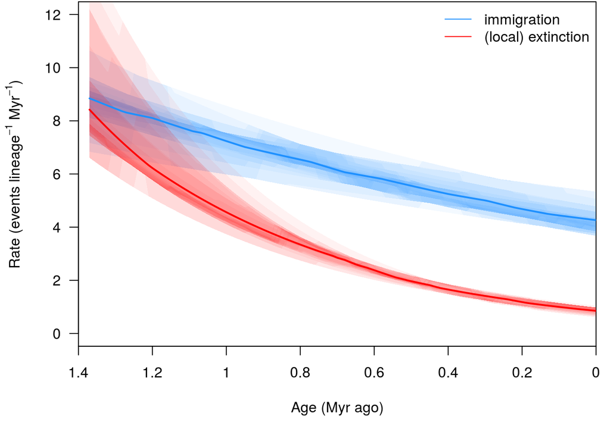

```r
system(paste0("python2 PyRate/PyRateDES2.py",
              " -d Results/DES/DESin.txt",
              " -mG ", # Preservation heterogeneity
              " -qtimes 11.5 8.66 4.55", # Shifts in sampling rate
              " -data_in_area 1", # Observations only in Ohrid
              " -varD Results/DES/Time.txt", # Time-variable dispersal
              " -varE Results/DES/Time.txt", # Time-variable (local) extinction
              " -n 2501 -s 100 -p 1000"))

Cov <- Time
Cov[, 2] <- Cov[, 2] - mean(Cov[, 2])

DesBi <- read.table("Results/DES/DESin_0_q_4.55_8.66_11.5_Dexp_Eexp_G.log",
                    header = TRUE, sep = "\t")
DesBi <- DesBi[DesBi$it >= 500, ] # Burn-in
DisThroughTimeBi <- apply(DesBi[, c("d21_t0", "cov_d21")], 1, function(x) x[1] * exp(x[2] * Cov$Cov))
DisThroughTimeBi <- 10 * DisThroughTimeBi
ExThroughTimeBi <- apply(DesBi[, c("e1_t0", "cov_e1")], 1, function(x) x[1] * exp(x[2] * Cov$Cov))
ExThroughTimeBi <- 10 * ExThroughTimeBi
Prob <- seq(0.95, 0.05, by = -0.05)
ExThroughTimeHpd <- DisThroughTimeHpd <- vector(mode = "list", length(Prob))
for(i in 1:length(Prob)){
  DisThroughTimeHpd[[i]] <- apply(DisThroughTimeBi, 1,
                                  function(x) HPDinterval(coda:::mcmc(x), prob = Prob[i]))
  ExThroughTimeHpd[[i]] <- apply(ExThroughTimeBi, 1,
                                 function(x) HPDinterval(coda:::mcmc(x), prob = Prob[i]))
}

par(las = 1, mar = c(5.1, 4.5, 0.1, 0.8))
plot(1, 1, type = "n",
     xlim = c(14, 0), ylim = c(0, 12), xaxs = "i", xaxt = "n",
     ylab = expression(paste("Rate (events ", lineage^{-1}, " ", Myr^{-1}, ")")),
     xlab = "Age (Myr ago)")
axis(side = 1, at = seq(14, 0, by = -2), labels = seq(1.4, 0, by = -0.2))
for(i in 1:length(DisThroughTimeHpd)){
  polygon(c(Time$Time, rev(Time$Time)),
          c(DisThroughTimeHpd[[i]][1, ], rev(DisThroughTimeHpd[[i]][2, ])),
          col = adjustcolor("dodgerblue", alpha = 1/length(Prob)), border = NA)
}
for(i in 1:length(DisThroughTimeHpd)){
  polygon(c(Time$Time, rev(Time$Time)),
          c(ExThroughTimeHpd[[i]][1, ], rev(ExThroughTimeHpd[[i]][2, ])),
          col = adjustcolor("red", alpha = 1/length(Prob)), border = NA)
}
lines(Time$Time, apply(DisThroughTimeBi, 1, median), col = "dodgerblue", lwd = 2)
lines(Time$Time, apply(ExThroughTimeBi, 1, median), col = "red", lwd = 2)
legend("topright", lty = c(1,1), col = c("dodgerblue", "red"),
       legend = c("immigration", "(local) extinction"), bty = "n")
```

We then inferred the average non-endemic richness through time by running 1,000 stochastic diversity simulations based on the estimated dispersal, local extinction and sampling parameters, using the R package ‘simDES’ 0.1 ([Hauffe 2019](https://github.com/thauffe/simDES)).

Due to computational limits we will only perform 100 stochastic diversity simulations here.

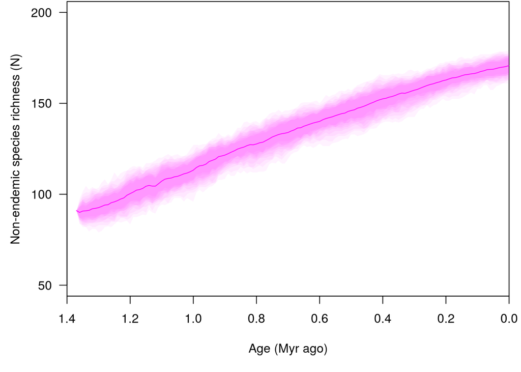

```r
Boot <- boot_DES(100, Time = 13.7, Step = 0.1, BinSize = 0.5, Nspecies = 202,
                 # ML parameters
                 SimD = c(0, DesResult$d21_t0),
                 SimE = c(DesResult$e1_t0, 0),
                 SimQ = c(1, 1),
                 VarD = c(0, DesResult$cov_d21),
                 VarE = c(DesResult$cov_e1, 0),
                 Covariate = Time,
                 # First time-bin with almost perfect preservation
                 # and thus we start with the observed richness of 91 species
                 Observation = data.frame(time = rep(13.7, 202),
                                          area = c(rep(2, 111), rep(3, 91))),
                 DataInArea = 1,
                 ConfInt = seq(0.95, 0.5, by = -0.05),
                 Ncores = 2)

par(las = 1, mar = c(5.1, 4.5, 0.1, 0.8))
plot(1, 1, type = "n",
     xlim = c(1.4, 0), ylim = c(50, 200), xaxs = "i",
     ylab = "Non-endemic species richness (N)",
     xlab = "Age (Myr ago)")
LenCi <- length(Boot[[3]])
TimeSim <- as.numeric(rownames(Boot[[2]])) / 10
for (i in 1:LenCi) {
  polygon(c(TimeSim, rev(TimeSim)),
          c(Boot[[3]][[i]][[3]][, 1], rev(Boot[[3]][[i]][[3]][, 2])),
          col = adjustcolor("magenta", alpha = 0.5/LenCi),
          border = NA)
}
lines(TimeSim, Boot[[2]][, 3], col = "magenta")
```

Safe non-endemic richness as biotic covariate for the drivers of diversification.

```r
TimeSeq <- seq(13.66, 0, length.out = 2000)
DivAppr <- approx(TimeSim, Boot[[2]]$MeanSimDivAB, xout = TimeSeq)$y
NonEnd <- data.frame(time = TimeSeq, NonEnd = DivAppr)
write.table(NonEnd,
            file = "Results/Covariates/NonEnd.txt",
            sep = "\t", row.names = FALSE, quote = FALSE)
```

### Plattform and resources

```r
Sys.time()
```

```
## [1] "2020-01-03 18:33:13 CET"
```